# Отчёт по лабораторной работе №13

Фильтр пакетов (firewalld)

Ришард Когенгар

Российский университет дружбы народов, Москва, Россия

22 января 2026

# Цель работы

## Основная цель

Получить навыки настройки пакетного фильтра в Linux и освоить управление межсетевым экраном **firewalld**: - через командную строку (**firewall-cmd**); - через графический интерфейс (**firewall-config**).

# Ход выполнения работы

## Управление брандмауэром с помощью firewall-cmd

- Получены полномочия администратора (root)
- Определена зона по умолчанию: **public**
- Просмотрены:
  - доступные зоны
  - доступные службы
  - службы в активной зоне

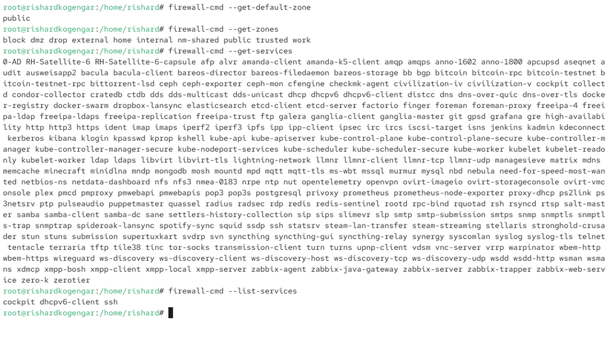

Определение зоны и просмотр зон/служб

## Проверка конфигурации зоны public

- Сравнены результаты:
  - просмотр конфигурации активной зоны
  - просмотр конфигурации явно указанной зоны **public**

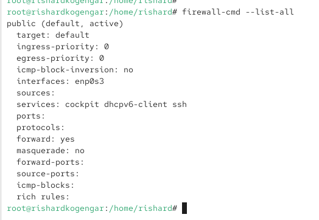

Конфигурация активной зоны

## Проверка конфигурации зоны public

- Подтверждено: **public** является зоной по умолчанию и активной

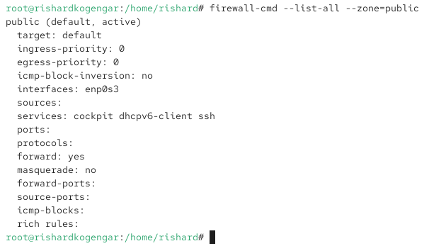

Конфигурация зоны public

## Добавление vnc-server во runtime-конфигурацию

- Служба **vnc-server** добавлена в конфигурацию **времени выполнения**
- Проверено наличие службы в списке разрешённых сервисов зоны **public**

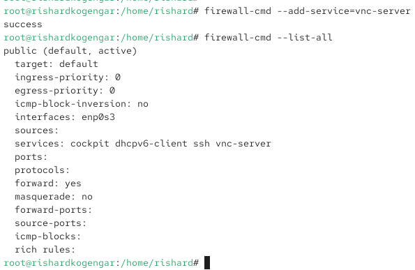

Добавление vnc-server и проверка

## Сброс runtime-изменений после перезапуска firewalld

- Выполнен перезапуск службы **firewalld**
- Установлено: **vnc-server** исчез из конфигурации
- Причина: изменения были внесены только во **runtime**, без сохранения в **permanent**

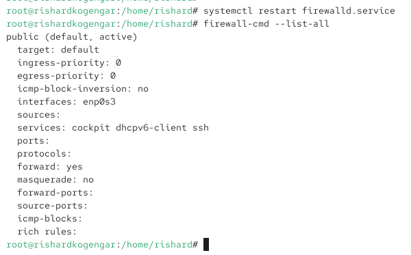

Отсутствие vnc-server после restart

## Добавление vnc-server в permanent-конфигурацию

- Служба **vnc-server** добавлена как **permanent**
- Проверка показала: во runtime конфигурации служба не отображается без перезагрузки правил

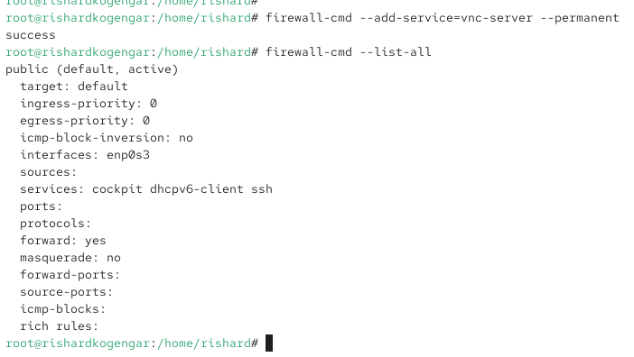

Permanent-добавление без применения

## Применение permanent-конфигурации

- Выполнено применение постоянных правил (reload)
- Подтверждено: **vnc-server** активен в зоне **public**

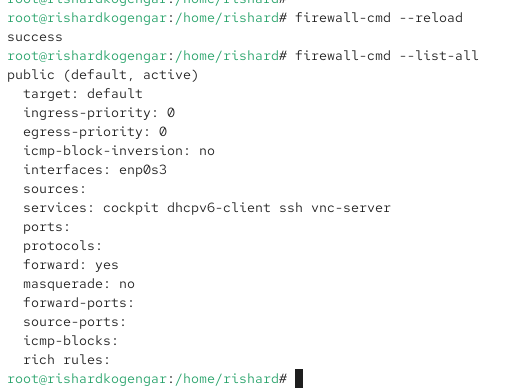

Применение permanent-конфигурации

## Добавление TCP-порта 2022

- В permanent-конфигурацию добавлен порт **2022/tcp**
- После применения правил подтверждено отображение порта в конфигурации зоны

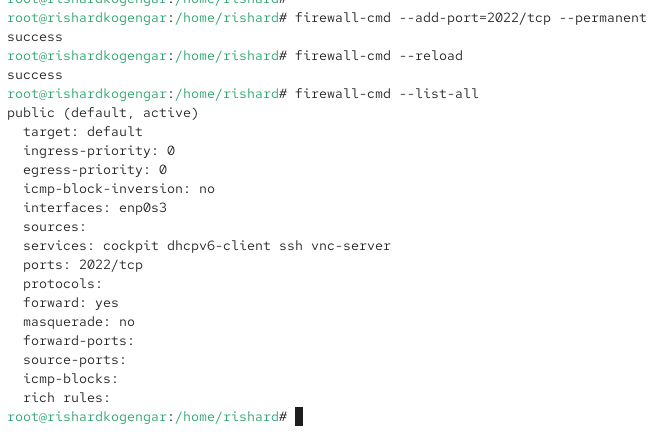

Добавление 2022/tcp и проверка

## Управление брандмауэром с помощью firewall-config

- Запущена утилита **firewall-config**
- Режим **Configuration: Permanent** выбран для сохранения изменений на диске
- Зона: **public**
- Включены службы: **http**, **https**, **ftp**

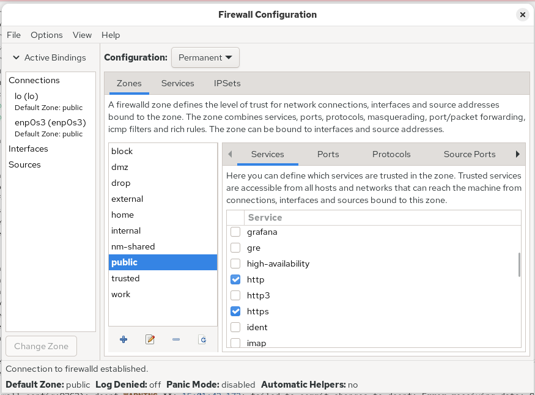

Включение служб http/https/ftp (Permanent)

## Добавление порта 2022/udp в GUI

- На вкладке **Ports** выполнено добавление:
  - Port: **2022**
  - Protocol: **udp**

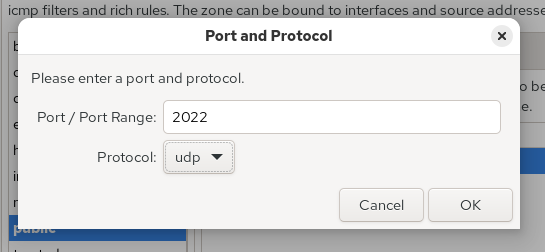

Добавление 2022/udp через GUI

## Проверка: permanent-изменения не активны без reload

- После закрытия firewall-config выполнена проверка конфигурации
- Установлено: изменения ещё не применены к конфигурации времени выполнения

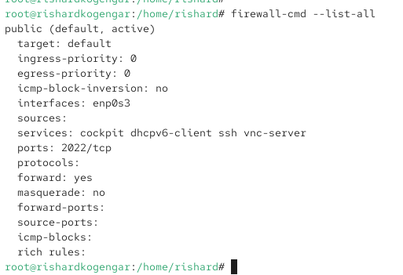

Проверка до reload

## Применение изменений после reload

- Выполнено применение правил
- Подтверждено:
  - службы **http/https/ftp** активны
  - порт **2022/udp** активен

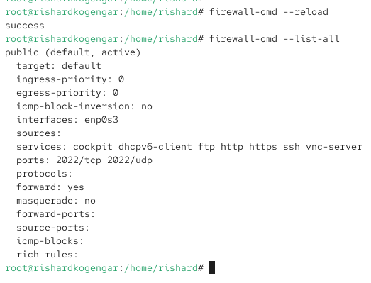

Проверка после reload

## Добавление imap/pop3/smtp через GUI

- Зона: **public**
- Режим: **Permanent**
- Отмечены службы: **imap**, **pop3**, **smtp**

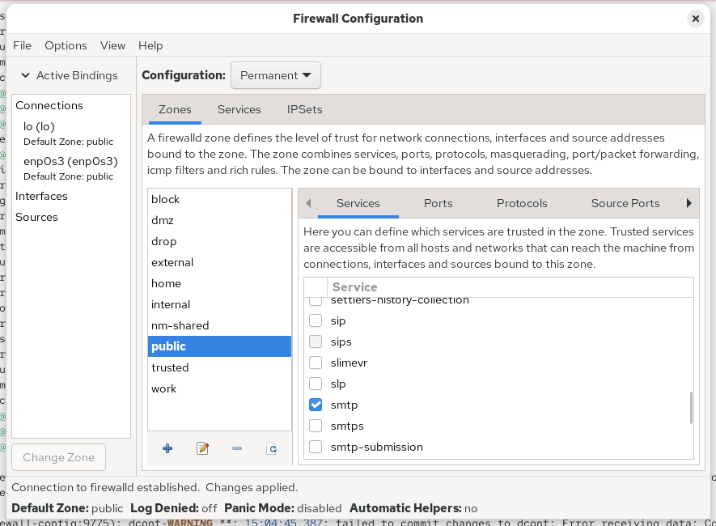

Добавление служб imap/pop3/smtp в GUI

## Добавление telnet через CLI и итоговая проверка

- telnet добавлен в **permanent**, затем применён (reload)
- Итоговая проверка подтвердила наличие:
  - сервисов (включая telnet, imap, pop3, smtp)
  - портов (2022/tcp, 2022/udp)

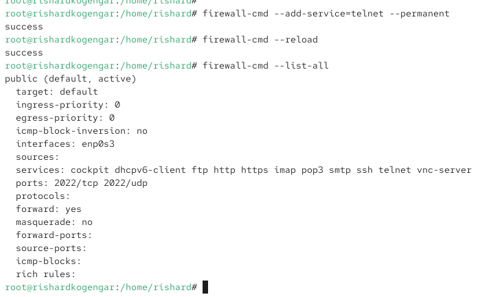

Итоговая конфигурация (telnet + services + ports)

# Итоги работы

## Вывод

- Освоены два подхода к управлению firewalld: **firewall-cmd** и **firewall-config**
- Показано различие между:
  - конфигурацией **времени выполнения** (runtime)
  - **постоянной** конфигурацией (permanent)
- Настроена постоянная конфигурация, обеспечивающая доступ к требуемым службам и портам, и корректно применяемая после **reload/перезагрузки**